# LAB 4 - PARTE 2

Anne Gabriele Arcanjo

7/4/2019

# Sobre os dados a serem descritos

Fonte dos dados:

- IDH Mundial http://hdr.undp.org/en/composite/HDI (2017)
- Indice de Liberdade https://www.heritage.org/index/excel/2019/index2019_data.xls (2019)

# Captura e Setup dos dados

```r
index2019_hdi2017_data = read_csv(here::here("data/index2019_hdi2017_data.csv"),
                                  col_types = "cccccccccccccccccccccccccccccccccccccccc")

dados_selecionados = index2019_hdi2017_data %>% select(1,3,4,5,6,14,15,16,30,35,36,37,39)
dados_selecionados = dados_selecionados %>%
  filter(`World Rank` !=  "N/A")

dados_analisados <- data_frame(
  ID = as.double(dados_selecionados$CountryID),
  pais = dados_selecionados$WEBNAME,
  regiao = dados_selecionados$Region,
  rank_liberdade = as.double(dados_selecionados$`World Rank`),
  rank_liberdade_regiao = as.double(dados_selecionados$`Region Rank`),
  liberdade_empreender = as.double(dados_selecionados$`Business Freedom`),
  liberdade_trabalho = as.double(dados_selecionados$`Labor Freedom`),
  liberdade_monetaria = as.double(dados_selecionados$`Monetary Freedom`),
  pib_per_capita = as.double(dados_selecionados$`GDP per Capita (PPP)`),
  idh = as.double(dados_selecionados$hdi),
  rank_idh = as.double(dados_selecionados$hdi_rank),
  expectativa_vida = as.double(dados_selecionados$life_expenctancy),
  expectativa_media_estudos = as.double(dados_selecionados$mean_years_schooling)
  )
```

# Ajuste dos Dados

```r
dados_analisados$expectativa_vida = log(dados_analisados$expectativa_vida)
dados_analisados$pib_per_capita = log(dados_analisados$pib_per_capita)
dados_analisados = dados_analisados %>%
  filter(liberdade_monetaria > 0)
```

# Visualizações - RANK DE LIBERADE

### PIB per Capita dado a Posição no Rank Mundial de Liberdade

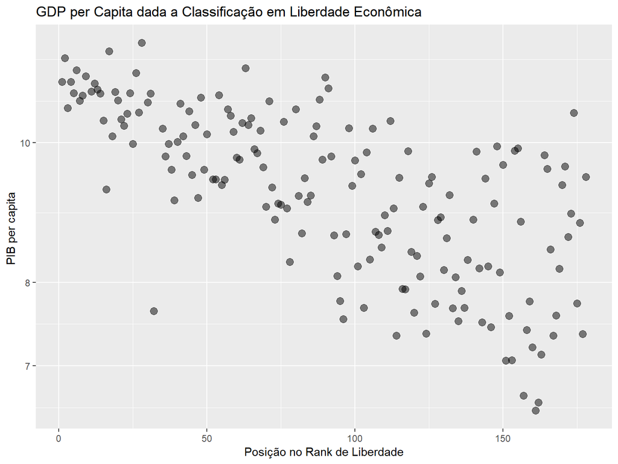

### IDH dado a Posição no Rank Mundial de Liberdade

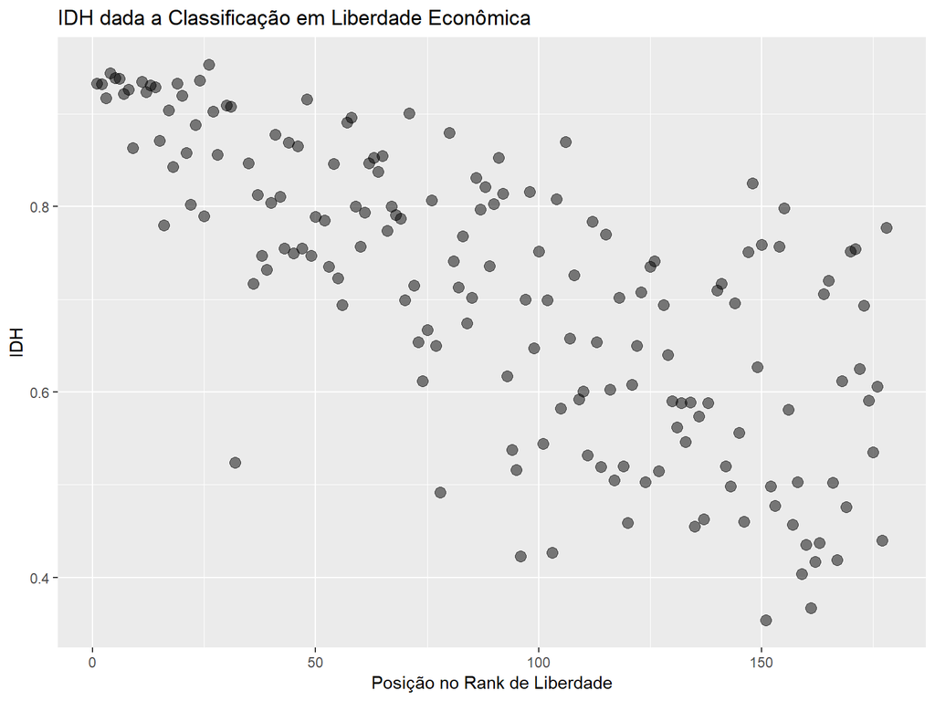

# Business Freedom

#### Liberdade para Empreender

É um indicador geral da eficiência da regulamentação governamental de negócios. A pontuação quantitativa é derivada de uma matriz de medidas da dificuldade de iniciar, operar e fechar um negócio. A pontuação de liberdade de negócios para cada país é um número entre 0 e 100, com 100 igualando-se ao ambiente de negócios mais livre. A pontuação é baseada em 10 fatores, todos ponderados de forma igual, usando dados do estudo Doing Business do Banco Mundial:

- Iniciar um negócio - procedimentos (número);
- Começar um negócio - tempo (dias);
- Iniciando um negócio - custo (% da renda per capita);
- iniciar um negócio - capital mínimo (% da renda per capita);
- Obtenção de uma licença - procedimentos (número); 1
- Obtenção de uma licença - tempo (dias);
- Obtenção de uma licença - custo (% da renda per capita);
- Fechando um negócio - tempo (anos);
- Fechamento de um negócio - custo (% da renda); e
- Fechamento de um negócio - taxa de recuperação (centavos por dólar) .2

Para mais detalhes sobre a formulação dos dados: https://www.heritage.org/index/business-freedom

# Visualizações - LIBERDADE PARA EMPREENDER

### PIB per Capita dado a Liberdade para Empreender

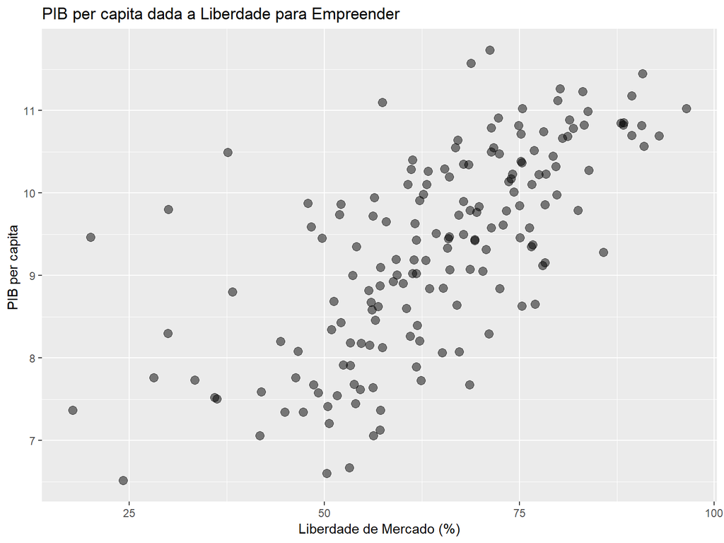

### IDH dado a Liberdade para Empreender

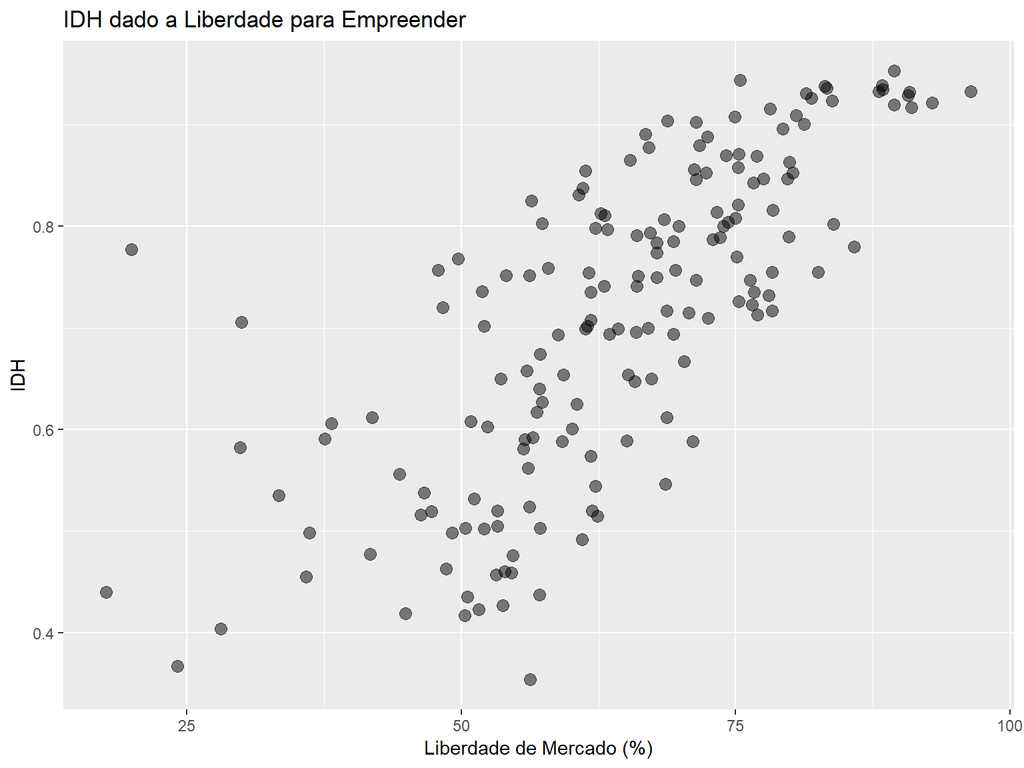

# Labor Freedom

#### Liberdade de Trabalho

O componente de liberdade trabalhista é uma medida quantitativa que considera vários aspectos do arcabouço legal e regulatório do mercado de trabalho de um país, incluindo regulamentações relativas a salários mínimos, leis que inibem demissões, exigências de demissão e restrições normativas mensuráveis na contratação e horas trabalhadas.

Seis fatores quantitativos são igualmente ponderados, cada um contado como um sexto do componente de liberdade de trabalho:

- Rácio do salário mínimo para o valor acrescentado médio por trabalhador,
- impedimento de contratar trabalhadores adicionais,
- rigidez de horas,
- Dificuldade de demitir funcionários redundantes,
- Período de notificação legalmente obrigatório e
- indenização compulsória.

Para mais detalhes sobre a formulação dos dados: https://www.heritage.org/index/labor-freedom

# Visualizações - LIBERDADE DE TRABALHO

### GDP per Capita dado a Liberdade de Trabalho

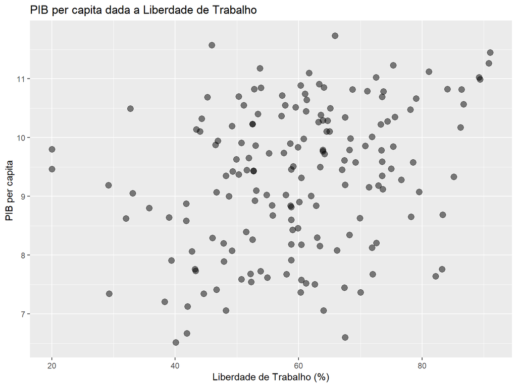

### IDH dado a Liberdade de Trabalho

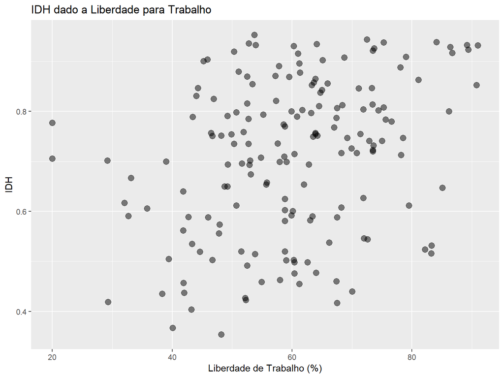

# Monetary Freedom

#### Liberdade de Monetária

A liberdade monetária combina uma medida de estabilidade de preços com uma avaliação dos controles de preços. Tanto a inflação quanto os controles de preços distorcem a atividade do mercado. Estabilidade de preços sem intervenção microeconômica é o estado ideal para o livre mercado.

A pontuação para o componente liberdade monetária é baseada em dois fatores:

- A taxa de inflação média ponderada para os três anos mais recentes e
- Controles de preço.

Para mais detalhes sobre a formulação dos dados: https://www.heritage.org/index/monetary-freedom

# Visualizações - LIBERDADE MONETÁRIA

### GDP per Capita dado a Liberdade Monetária

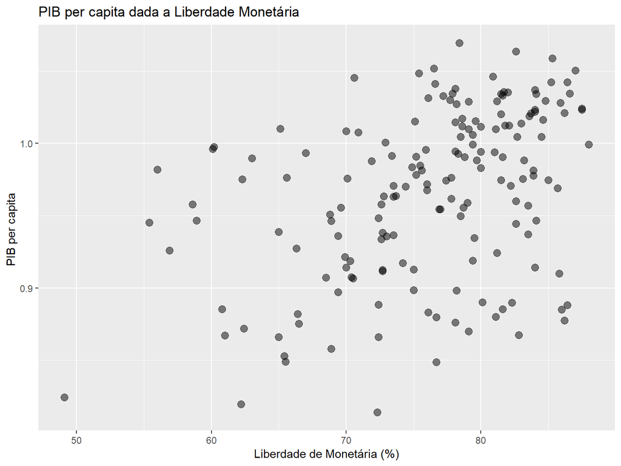

### IDH dado a Liberdade Monetária

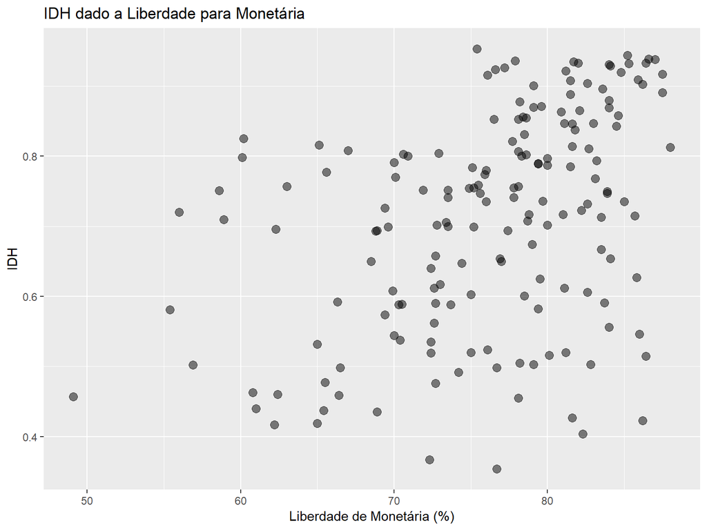

# Visualizações - EXPECTATIVA MÉDIA DE ANOS DE ESTUDO

### GDP per Capita dado a Expectativa Média de Anos de Estudo

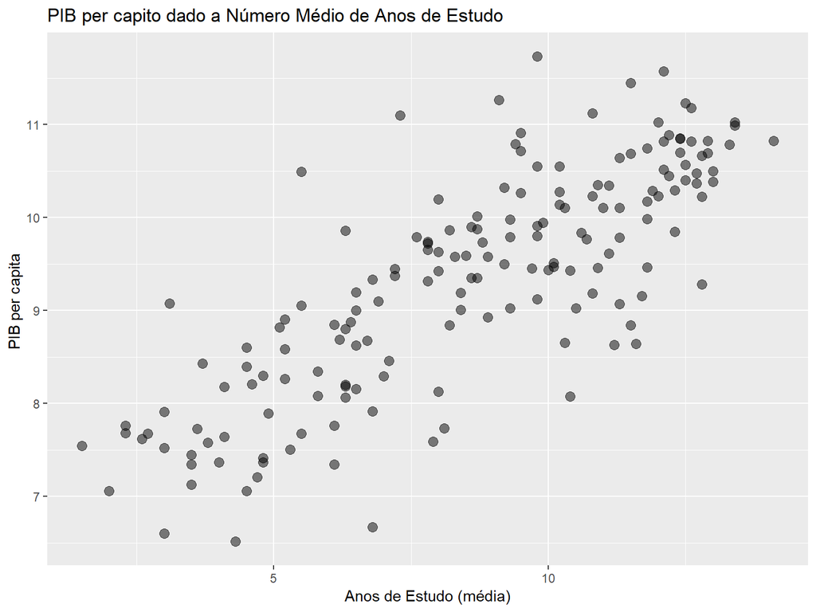

### IDH dado a Expectativa Média de Anos de Estudo

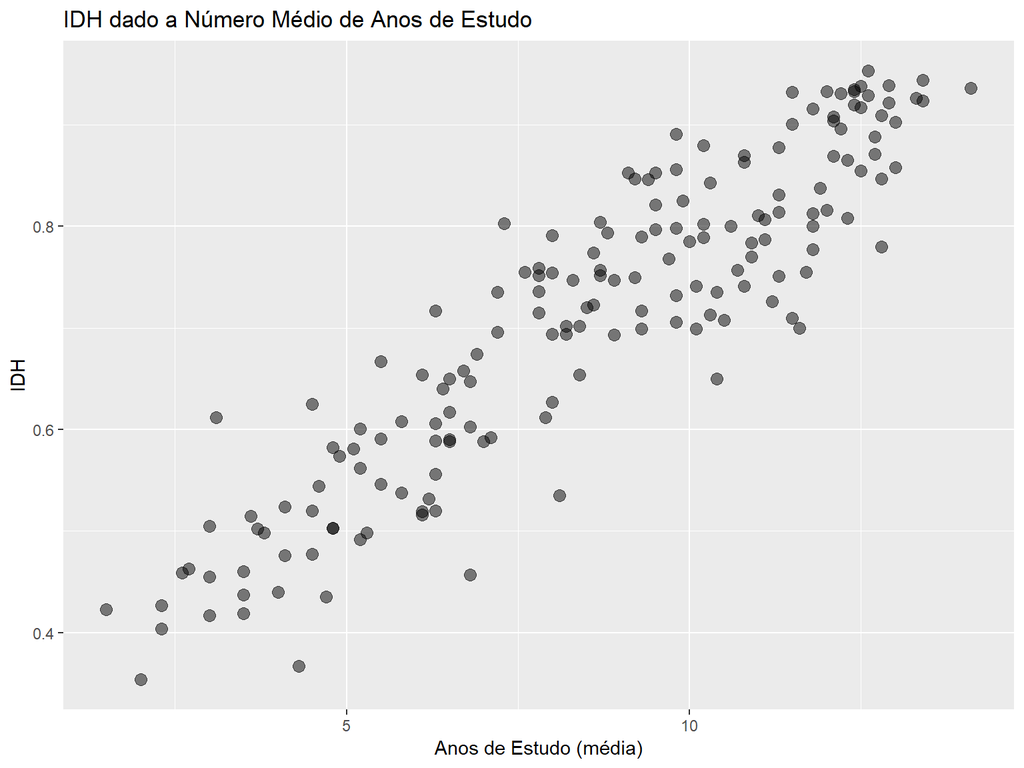

# Visualizações - EXPECTATIVA VIDA

### GDP per Capita dado a Expectativa de Vida

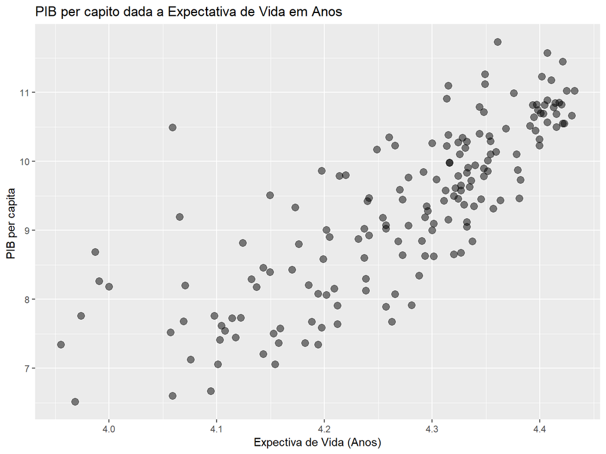

### IDH dado a Expectativa de Vida

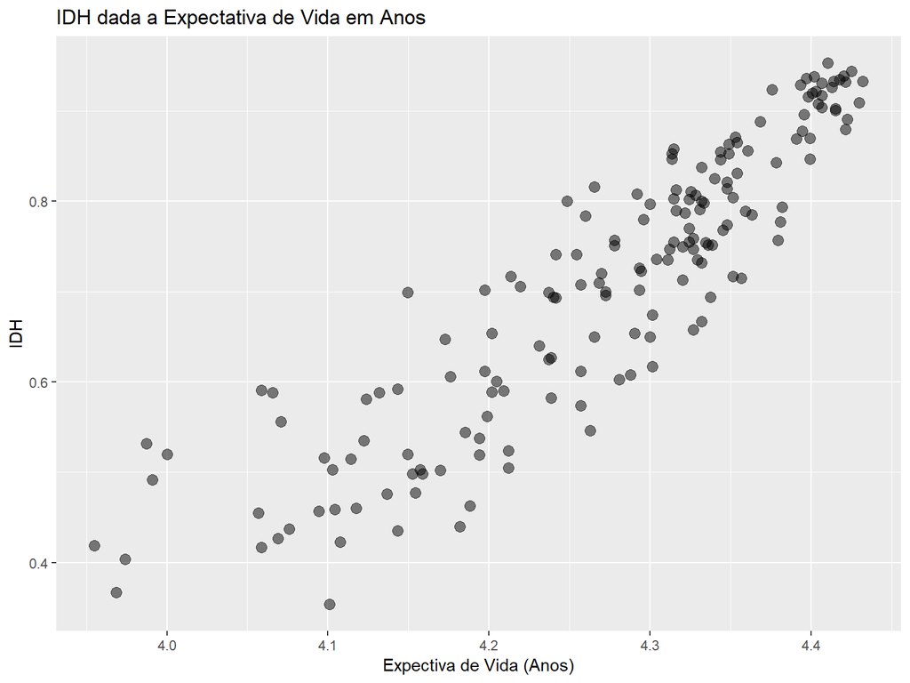

# Geração de Modelos

### MODELO PIB PER CAPITA:

```
## # A tibble: 7 x 7
##   term            estimate std.error statistic   p.value conf.low conf.high
##   <chr>              <dbl>     <dbl>     <dbl>     <dbl>    <dbl>     <dbl>
## 1 (Intercept)    -8.47       2.96       -2.86    4.79e-3 -1.43e+1 -2.62
## 2 rank_liberdade -0.00326    0.00175    -1.87    6.38e-2 -6.71e-3  0.000189
## 3 liberdade_emp~  0.00533    0.00544     0.979   3.29e-1 -5.42e-3  0.0161
## 4 liberdade_tra~ -0.000493   0.00402    -0.123   9.02e-1 -8.43e-3  0.00744
## 5 liberdade_mon~  0.00860    0.00756     1.14    2.57e-1 -6.33e-3  0.0235
## 6 expectativa_m~  0.148      0.0252      5.88    2.21e-8  9.84e-2  0.198
## 7 expectativa_v~  3.71       0.717       5.18    6.43e-7  2.30e+0  5.13
```

```
## # A tibble: 1 x 11
##   r.squared adj.r.squared sigma statistic  p.value    df logLik   AIC   BIC
##       <dbl>         <dbl> <dbl>     <dbl>    <dbl> <int>  <dbl> <dbl> <dbl>
## 1     0.750         0.741 0.614      81.9 8.80e-47     7  -156.  327.  352.
## # ... with 2 more variables: deviance <dbl>, df.residual <int>
```

# Geração de Modelos

### MODELO IDH :

A determinação da *posição no rank de liberdade*, DECRESCE em 1,1e-04 o valor da VarDep IDH.

O ganho de 1% em *liberdade de empreender*, *liberdade de trabalho* e *liberdade monetaria* produzem um ACRÉSCIMO de 8,2e-04, 4,15e-05 e 7,8e-04, respectivamente, no valor do IDH.

A cada *ano de estudo* o IDH CRESCE em 2,4e-02.

O logarítimo de cada *ano ganho na expectativa de vida* AUMENTAM em 5,8e-01 o IDH.

```
## # A tibble: 7 x 7
##   term             estimate std.error statistic  p.value conf.low conf.high
##   <chr>               <dbl>     <dbl>     <dbl>    <dbl>    <dbl>     <dbl>
## 1 (Intercept)      -2.08e+0  0.182      -11.4   1.29e-22 -2.44e+0 -1.72
## 2 rank_liberdade   -1.09e-4  0.000107    -1.02  3.10e- 1 -3.21e-4  0.000103
## 3 liberdade_empr~   8.23e-4  0.000334     2.46  1.49e- 2  1.63e-4  0.00148
## 4 liberdade_trab~   4.15e-5  0.000247     0.168 8.66e- 1 -4.46e-4  0.000529
## 5 liberdade_mone~   7.75e-4  0.000464     1.67  9.67e- 2 -1.41e-4  0.00169
## 6 expectativa_me~   2.46e-2  0.00155     15.9   3.99e-35  2.16e-2  0.0277
## 7 expectativa_vi~   5.79e-1  0.0440      13.2   1.87e-27  4.92e-1  0.666
```

```
## # A tibble: 1 x 11
##   r.squared adj.r.squared  sigma statistic  p.value    df logLik   AIC
##       <dbl>         <dbl>  <dbl>     <dbl>    <dbl> <int>  <dbl> <dbl>
## 1     0.942         0.940 0.0377      447. 6.81e-99     7   322. -627.
## # ... with 3 more variables: BIC <dbl>, deviance <dbl>, df.residual <int>
```

### Análise Descritiva dos Países Classificados como África Sub Sariana

```
## # A tibble: 47 x 15
##       ID pais  regiao rank_liberdade rank_liberdade_~ liberdade_empre~
##    <dbl> <chr> <chr>           <dbl>            <dbl>            <dbl>
##  1     4 Ango~ Sub-S~            156               33             55.7
##  2    17 Benin Sub-S~            127               21             62.4
##  3    21 Bots~ Sub-S~             36                3             68.7
##  4    24 Burk~ Sub-S~             96                9             51.6
##  5    26 Buru~ Sub-S~            162               39             50.3
##  6    28 Came~ Sub-S~            145               29             44.4
##  7    30 Cabo~ Sub-S~             73                4             65.2
##  8    31 Cent~ Sub-S~            161               38             24.2
##  9    32 Chad  Sub-S~            159               36             28.1
## 10    36 Como~ Sub-S~            124               20             57.2
## # ... with 37 more rows, and 9 more variables: liberdade_trabalho <dbl>,
## #   liberdade_monetaria <dbl>, pib_per_capita <dbl>, idh <dbl>,
## #   rank_idh <dbl>, expectativa_vida <dbl>,
## #   expectativa_media_estudos <dbl>, pred <dbl>, resid <dbl>
```

[output not shown]